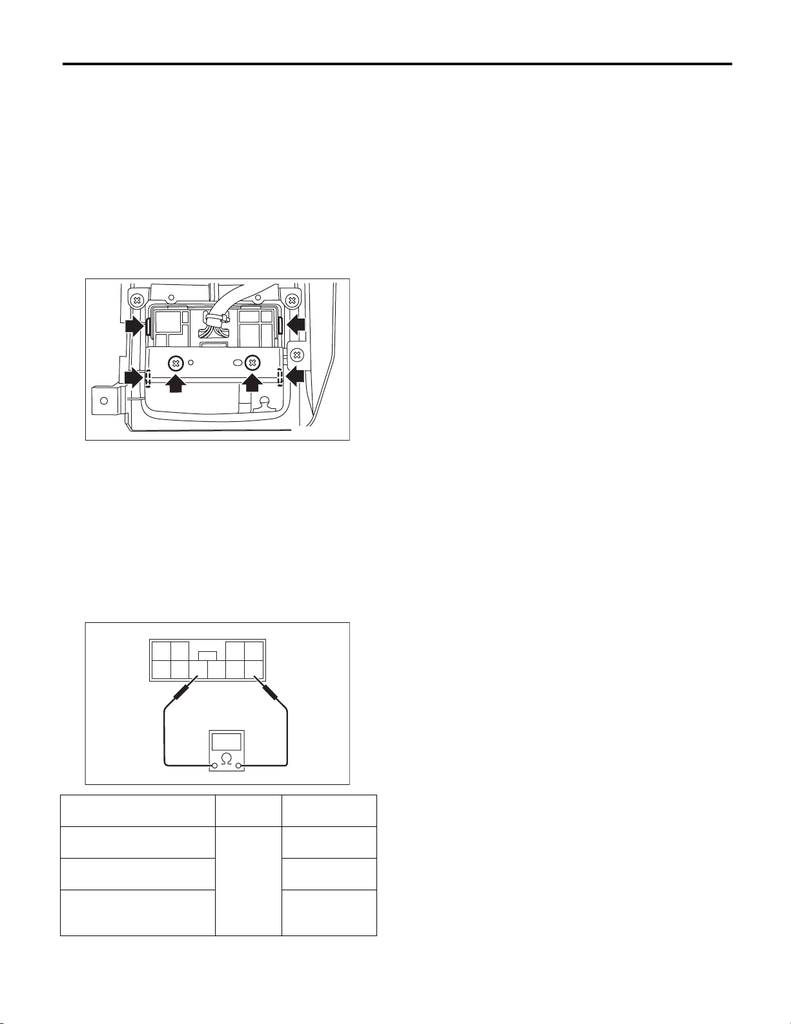

SI-DRIVE (SUBARU Intelligent Drive) Selector

FUEL INJECTION (FUEL SYSTEMS)

18.SI-DRIVE (SUBARU Intelli-

gent Drive) Selector

A: REMOVAL

1) Disconnect the ground cable from battery.

2) Remove the console box. <Ref. to EI-67, RE-

MOVAL, Console Box.>

3) Remove the multi-selector switch connector

from the console box.

4) Remove the screws and tabs holding the multi-

selector switch to the console box and the multi-se-

lector switch.

B: INSTALLATION

Install in the reverse order of removal.

Tightening torque:

1.5 N·m (0.2 kgf-m, 1.1 ft-lb)

C: INSPECTION

1) Check that the multi select switch does not have

deformation, cracks, or damage.

2) Check the resistance between the terminals at

the SI-DRIVE selector.

Switch position

Terminal

No.

Standard

Sport (When turning the SI-

DRIVE selector to the left)

5 and 8

Less than 1 Ω

Intelligent (When pressing

the SI-DRIVE selector)

1±0.05 kΩ

Sport Sharp (When turning

the SI-DRIVE selector to the

right)

3.67±0.1835 kΩ

4

5

3 2 1

9 8 7 6

10